# R_Training_3.5

# Exercise 12: Spikes

In this exercise we will take a recording of a neural activity (spikes!) and turn it into data that we can start to analyze in useful ways.

I have provided two sample files that contain some nice neural activity. They are very different from each other.

Read the first file, make the time data, and plot (easy by now).

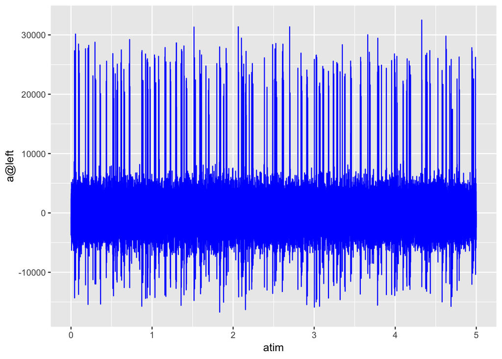

```r
a = readWave("spikes1.wav")
aFs = a@samp.rate
atim = seq(1/aFs, length(a)/aFs, 1/aFs)

ggplot() +
  geom_line(aes(x = atim, y = a@left), colour = "Blue")
```

Lets zoom in on a second of the data…

*Note: This can be done several ways. The first way is to us **p + scale_x_continuous(limits = c(3,4))**. This way will remove all points not plotted. You can use **xlim(3,4)** as a shorthand version of this same function. The method we use is **p + coord_cartesian(xlim = c(3,4))**, which PRESERVES data points not plotted. This may be relevant if you are fitting anything to the data.*

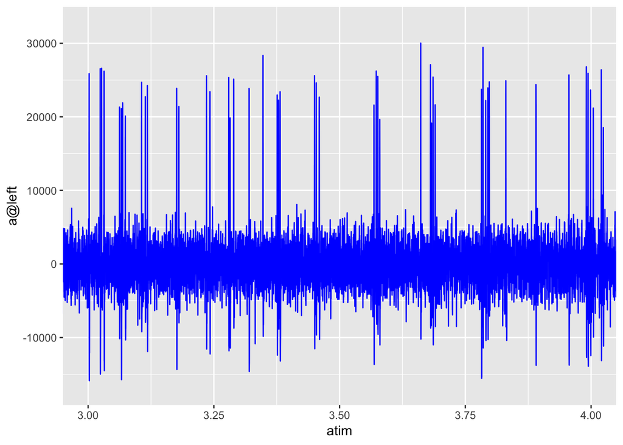

```r
ggplot() +
  geom_line(aes(x = atim, y = a@left), colour = "Blue") +
  coord_cartesian(xlim = c(3,4))
```

Now lets set and amplitude threshold for the spikes. Different recordings have different amplitudesfor spikes. Here I guessed **15000**. Lets look at the plot to confirm.

```r
athresh = 15000
```

We will use the **which()** function to get all of the data above the threshold.

```r
spikes = which(a@left > athresh)
```

This is a complicated, but necessary step. Spikes are more than 1 or two milliseconds in duration. Thus, we want a threshold for the interval between spikes - anything less than that threshold is a mistake from the **which()* command.

Our threshold will be 1 millisecond: 0.001 seconds. Since are data is in samples and not in milliseconds, we’ll set our threshold to the **sample rate * milliseconds**.

**diff** is the difference between adjacent data points.

So, here we find all of the instances where the number of samples between spikes is greater than our threshold of 1 millisecond samples (which for Fs = 10000 is 10 samples).

```r
spikes1 = spikes[which(diff(spikes) > 0.001 * aFs)]
```

How many spikes did we find?

```r
length(spikes1)
```

```
## [1] 223
```

What is the spike rate?

```r
length(spikes1)/atim[length(atim)]
```

```
## [1] 44.59911
```

```r
ys = rep(1, length(spikes1)) * athresh
```

Now plot…

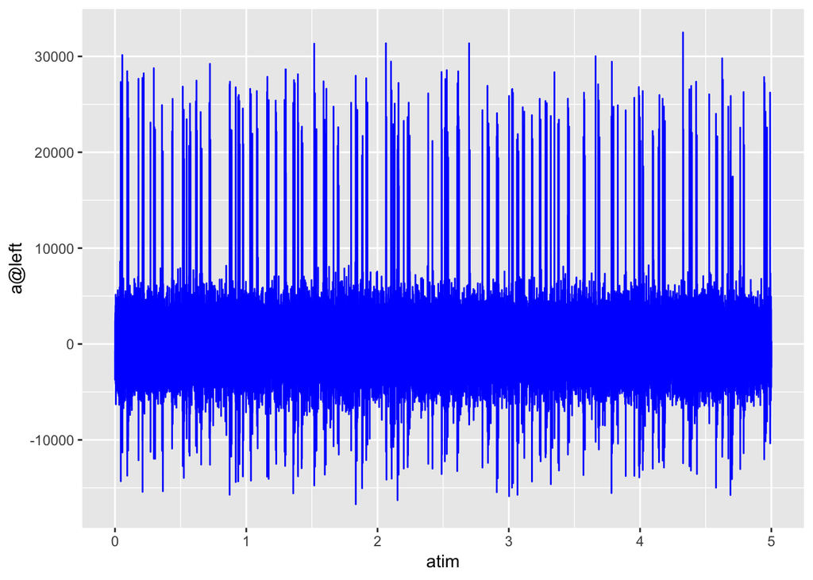

```r
ggplot() +
  geom_line(aes(x = atim, y = a@left), colour = "Blue")
```

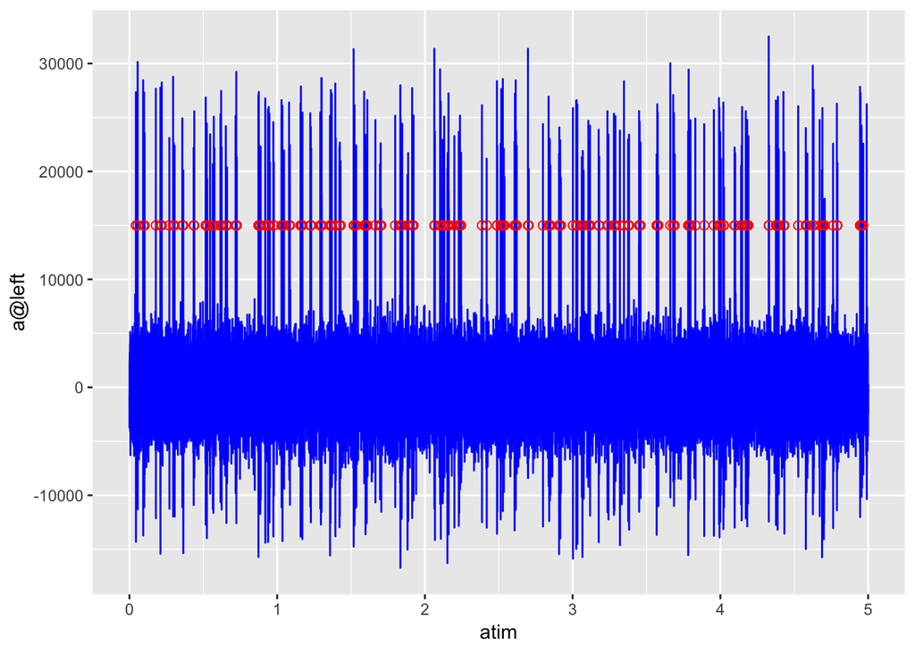

```r
ggplot() +
  geom_line(aes(x = atim, y = a@left), colour = "Blue") +
  geom_point(aes(x = atim[spikes1], y = ys), colour = "Red", size = 2, shape = 1)
```

Zoom in to get a better look!

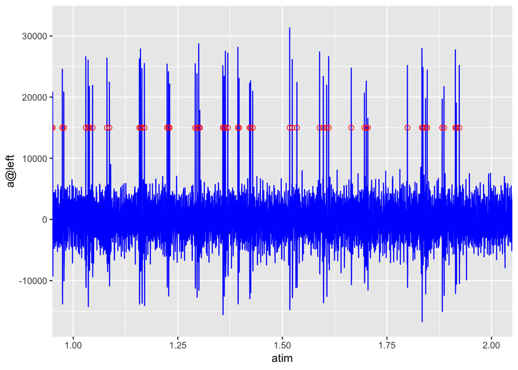

```r
ggplot() +
  geom_line(aes(x = atim, y = a@left), colour = "Blue") +
  geom_point(aes(x = atim[spikes1], y = ys), colour = "Red", size = 2, shape = 1) +
  coord_cartesian(xlim = c(1,2))
```

We can go even further…

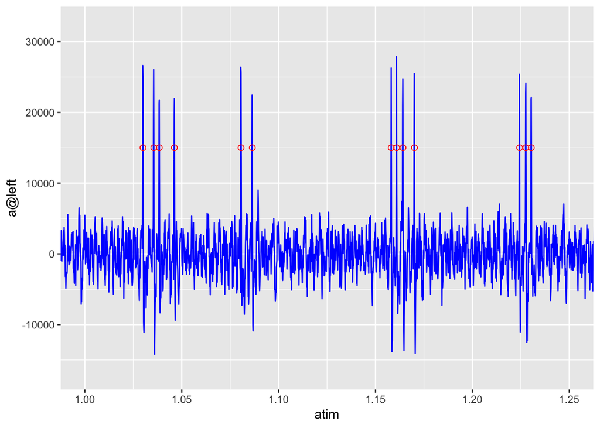

```r
ggplot() +
  geom_line(aes(x = atim, y = a@left), colour = "Blue") +
  geom_point(aes(x = atim[spikes1], y = ys), colour = "Red", size = 2, shape = 1) +
  coord_cartesian(xlim = c(1,1.25))
```

Another important measure is the time between spikes. This is very easy to get using the **diff()** command.

**diff()** will give use the number of samples between spikes, and then we divide by the sample rate to get the time, in seconds, between spikes.

```r
intervals1 = diff(spikes1)/aFs
```

Here are some easy measures.

```r
mean(intervals1)
```

```
## [1] 0.02217613
```

```r
pmax(intervals1)
```

[output not shown]

```r
pmin(intervals1)
```

[output not shown]

But looking at the plot we see that the spikes are in “bursts” rather than randomly spread. If they were randomly timed, we would find a random distribution of the intervals between spikes. Lets take a look using a histogram…

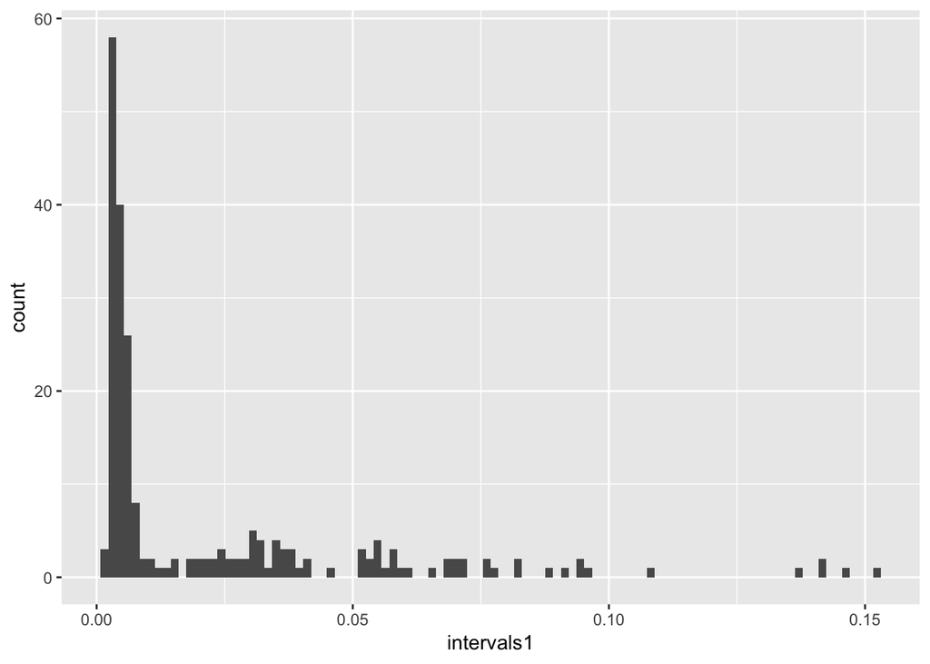

```r
ggplot() +
  geom_histogram(aes(x = intervals1), bins = 100)
```

For these data we see that there are many many intervals below 0.015 (15 milliseconds), and a spread of longer intervals. This plot is a very good example of a “bursty” neuron.

The other data, spikes2.wav, is very very different.

Please do the same analysis for those data as you did for **spikes1.wav**. Use different variable names like changing **spikes1** to **spikes2** and **interval1** to **interval2** so that you can plot a histogram just like we did above. Try plotting both histograms in the same frame.